# What makes a coffeehouse great? ☕ An analysis of user-submitted tips on Yelp.

#### By Leanne Hwa, Carol Cheng, Victoria Juan, and Kar Yin Ng

## Project description 🗺️

On Yelp, where anyone can submit and read reviews, businesses can and should leverage the user-submitted data to not only better understand their customer feedback, but the greater competitive market.Some parts of the customer feedback are easily quantified, such as the number of stars out of 5 given, the “useful”, “funny”, or “cool” votes. However, what the user includes in the text of their feedback is even more important, containing raw insights and even complaints about their experience.

For this project, we wanted to focus on Yelp tips: shorter than reviews, but quick and straight to the point with suggestions. As characteristic of rating-oriented feedback, Yelp reviews are typically skewed towards the extreme ends of the 5-star spectrum, with users frequently leaving reviews only when they have an awesome or terrible experience. However, with tips not tied to a rating, we saw an opportunity for analyzing this more objective source of feedback.

**The purpose of our research project is to better understand what’s in a tip, and what its content may infer about a business’ overall rating**. We’ve scoped our project down to analyzing tips for **coffee shops**. ☕

Our main research question is:

- **Is there a relationship between the attributes mentioned by users in tips and the business’ overall rating?**

Our sub-questions are:

- **What are commonly mentioned business attributes in tips?**
- **Does the context of an attribute in a tip vary across different business ratings?**

## Dataset description 📊

The dataset that we will be working with is a subset of Yelp’s businesses, reviews, and user data across 11 metropolitan areas in four countries. For this research study, we are specifically working with information about businesses (yelp_business.csv) and user-submitted tips (yelp_tip.csv). This dataset was originally collected for the Yelp Dataset Challenge where analyses and discoveries on Yelp’s data could be shared and made freely available. The dataset can be accessed and downloaded from Kaggle’s website ([link](https://www.kaggle.com/yelp-dataset/yelp-dataset))

Here is a glimpse of the business data, which includes identifier, geographical, and categorical information about a business:

|  | business_id | name | neighborhood | address | city | state | postal_code | latitude | longitude | stars | review_count | is_open | categories |
| --- | --- | --- | --- | --- | --- | --- | --- | --- | --- | --- | --- | --- | --- |
| 0 | FYWN1wneV18bWNgQjJ2GNg | "Dental by Design" | NaN | "4855 E Warner Rd, Ste B9" | Ahwatukee | AZ | 85044 | 33.330690 | -111.978599 | 4.0 | 22 | 1 | Dentists;General Dentistry;Health & Medical;Or... |
| 1 | He-G7vWjzVUysIKrfNbPUQ | "Stephen Szabo Salon" | NaN | "3101 Washington Rd" | McMurray | PA | 15317 | 40.291685 | -80.104900 | 3.0 | 11 | 1 | Hair Stylists;Hair Salons;Men's Hair Salons;Bl... |
| 2 | KQPW8lFf1y5BT2MxiSZ3QA | "Western Motor Vehicle" | NaN | "6025 N 27th Ave, Ste 1" | Phoenix | AZ | 85017 | 33.524903 | -112.115310 | 1.5 | 18 | 1 | Departments of Motor Vehicles;Public Services ... |
| 3 | 8DShNS-LuFqpEWIp0HxijA | "Sports Authority" | NaN | "5000 Arizona Mills Cr, Ste 435" | Tempe | AZ | 85282 | 33.383147 | -111.964725 | 3.0 | 9 | 0 | Sporting Goods;Shopping |
| 4 | PfOCPjBrlQAnz__NXj9h_w | "Brick House Tavern + Tap" | NaN | "581 Howe Ave" | Cuyahoga Falls | OH | 44221 | 41.119535 | -81.475690 | 3.5 | 116 | 1 | American (New);Nightlife;Bars;Sandwiches;Ameri... |

Here is a glimpse of the tips data:

|  | text | date | likes | business_id | user_id |
| --- | --- | --- | --- | --- | --- |
| 0 | Great breakfast large portions and friendly wa... | 2015-08-12 | 0 | jH19V2I9fIslnNhDzPmdkA | ZcLKXikTHYOnYt5VYRO5sg |
| 1 | Nice place. Great staff. A fixture in the tow... | 2014-06-20 | 0 | dAa0hB2yrnHzVmsCkN4YvQ | oaYhjqBbh18ZhU0bpyzSuw |
| 2 | Happy hour 5-7 Monday - Friday | 2016-10-12 | 0 | dAa0hB2yrnHzVmsCkN4YvQ | ulQ8Nyj7jCUR8M83SUMoRQ |
| 3 | Parking is a premium, keep circling, you will ... | 2017-01-28 | 0 | ESzO3Av0b1_TzKOiqzbQYQ | ulQ8Nyj7jCUR8M83SUMoRQ |
| 4 | Homemade pasta is the best in the area | 2017-02-25 | 0 | k7WRPbDd7rztjHcGGkEjlw | ulQ8Nyj7jCUR8M83SUMoRQ |

## Data exploration 🔎

After filtering for just *'Cafes'* and *'Coffee & Tea'* categories, we obtained a dataset which consists of:

- 6617 businesses on Yelp
- 89304 user-submitted tips ('text' column)

On average, each business receives **13.5** user-submitted tips on Yelp.

Below is a preview of the dataset that our analyses are based upon:

|  | business_id | city | state | stars | categories | text |
| --- | --- | --- | --- | --- | --- | --- |
| 0 | EsMcGiZaQuG1OOvL9iUFug | Wexford | PA | 5.0 | Coffee & Tea;Ice Cream & Frozen Yogurt;Food | Yummy |
| 1 | lHYiCS-y8AFjUitv6MGpxg | Toronto | ON | 4.0 | Food;Coffee & Tea | The Internet has been down at the Liberty Vill... |
| 2 | lHYiCS-y8AFjUitv6MGpxg | Toronto | ON | 4.0 | Food;Coffee & Tea | Great place to watch the beautiful people of L... |
| 3 | lHYiCS-y8AFjUitv6MGpxg | Toronto | ON | 4.0 | Food;Coffee & Tea | Place seems packed out around 1pm. Could be a ... |
| 4 | lHYiCS-y8AFjUitv6MGpxg | Toronto | ON | 4.0 | Food;Coffee & Tea | Saturday and Sunday mornings this is the place... |
| 5 | lHYiCS-y8AFjUitv6MGpxg | Toronto | ON | 4.0 | Food;Coffee & Tea | Get the extra shot of espresso!!!!!! |
| 6 | lHYiCS-y8AFjUitv6MGpxg | Toronto | ON | 4.0 | Food;Coffee & Tea | This is the worst Starbucks in the city! They ... |
| 7 | lHYiCS-y8AFjUitv6MGpxg | Toronto | ON | 4.0 | Food;Coffee & Tea | I love the redhead barista. |
| 8 | lHYiCS-y8AFjUitv6MGpxg | Toronto | ON | 4.0 | Food;Coffee & Tea | This is more of a tip for the staff there, nex... |
| 9 | AtdXq_gu9NTE5rx4ct_dGg | Toronto | ON | 4.0 | Coffee & Tea;Food;Tea Rooms | The entrance is actually off Yonge, not Dundas |

|  | business_id | city | state | stars | categories | text |
| --- | --- | --- | --- | --- | --- | --- |
| 89294 | pUhU5ohYv65g8B47dTXAKA | Las Vegas | NV | 2.5 | Coffee & Tea;Food | Jan 31st is the last day for the Jan tumbler p... |
| 89295 | pUhU5ohYv65g8B47dTXAKA | Las Vegas | NV | 2.5 | Coffee & Tea;Food | Casi Cielo is the bold drip for the week of 2\/4 |
| 89296 | pUhU5ohYv65g8B47dTXAKA | Las Vegas | NV | 2.5 | Coffee & Tea;Food | Nice staff |
| 89297 | pUhU5ohYv65g8B47dTXAKA | Las Vegas | NV | 2.5 | Coffee & Tea;Food | Collecting my holiday drink sticker for a free... |
| 89298 | pUhU5ohYv65g8B47dTXAKA | Las Vegas | NV | 2.5 | Coffee & Tea;Food | Good crew here. They're always nice and fairly... |
| 89299 | pUhU5ohYv65g8B47dTXAKA | Las Vegas | NV | 2.5 | Coffee & Tea;Food | Sometimes they get your order wrong or takes ... |
| 89300 | pUhU5ohYv65g8B47dTXAKA | Las Vegas | NV | 2.5 | Coffee & Tea;Food | If I order a LIGHT then NO I don't want whip c... |
| 89301 | pUhU5ohYv65g8B47dTXAKA | Las Vegas | NV | 2.5 | Coffee & Tea;Food | Drive thru! |
| 89302 | pUhU5ohYv65g8B47dTXAKA | Las Vegas | NV | 2.5 | Coffee & Tea;Food | Clean store, very friendly staff. |
| 89303 | pUhU5ohYv65g8B47dTXAKA | Las Vegas | NV | 2.5 | Coffee & Tea;Food | Have the employee Krystal fake a smile when gi... |

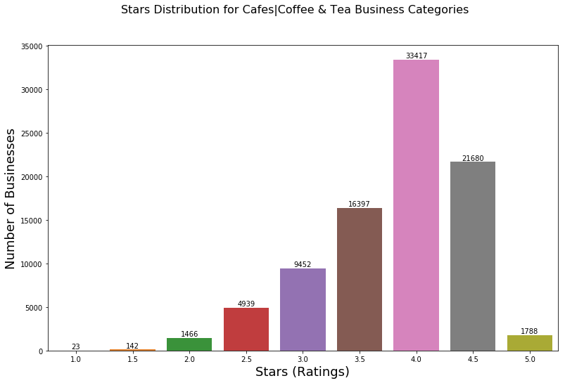

### What are some general trends for the tips dataset?

The 100 most frequently used words in tips are:

```
[('great', 12396),
 ('coffee', 10536),
 ('good', 8461),
 ('place', 8460),
 ('service', 6683),
 ('food', 6481),
 ('love', 5473),
 ('best', 5175),
 ('get', 5069),
 ('tea', 4283),
 ('try', 3699),
 ('friendly', 3561),
 ('delicious', 3557),
 ('amazing', 3413),
 ('nice', 3195),
 ('breakfast', 3158),
 ('staff', 3102),
 ('time', 2872),
 ('like', 2870),
 ('free', 2807),
 ('go', 2713),
 ('awesome', 2677),
 ('always', 2571),
 ('one', 2543),
 ('latte', 2391),
 ('starbucks', 2158),
 ('really', 2089),
 ('back', 2076),
 ('new', 2028),
 ('day', 2002),
 ('chocolate', 1970),
 ('order', 1892),
 ('iced', 1868),
 ('milk', 1856),
 ('location', 1837),
 ('come', 1797),
 ('ever', 1677),
 ('drink', 1674),
 ('open', 1667),
 ('fresh', 1665),
```

[output cut: 45 more lines]

```
 ('check', 961),
 ('vegan', 958),
 ('cafe', 953),
 ('perfect', 945),
 ('fast', 935),
 ('line', 928),
 ('sure', 926),
 ('ca', 926),
 ('worth', 922),
 ('work', 917),
 ('pretty', 916),
 ('customer', 909),
 ('happy', 908),
 ('well', 907),
 ('need', 906)]
```

We even created a word cloud in the shape of a coffee mug using the top 100 words! Looks to be pretty positive:

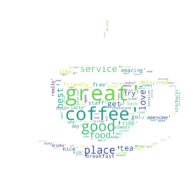

## Methods 📓

### What do users write about in tips?

To better understand the content of the tips in detail, from our top 100 words, we manually coded each word into **four categories**:

1. **Positive**: conventionally positive words, such as adjectives (“friendly”), verbs (“love”), and features (“free”)
2. **Negative**: conventionally negative words, such as adjectives (“slow”), verbs (“wait”)
3. **Neutral**: business features or descriptors, not tied to a feeling, such as “location”
4. **Eliminated**: stop-words (“go”, “get”), over-general words (“food”, “coffee”), or too niche words (“chicken”)

|  | positive | negative | neutral | eliminate |
| --- | --- | --- | --- | --- |
| 0 | great | wait | coffee | get |
| 1 | good | closed | place | try |
| 2 | love | busy | service | go |
| 3 | friendly | long | food | always |
| 4 | delicious | slow | tea | one |
| 5 | amazing | line | breakfast | starbucks |
| 6 | nice |  | staff | really |
| 7 | like |  | time | back |
| 8 | free |  | latte | day |
| 9 | awesome |  | chocolate | come |
| 10 | new |  | order | ever |
| 11 | fresh |  | milk | little |
| 12 | yummy |  | iced | make |
| 13 | super |  | location | today |
| 14 | excellent |  | drink | better |
| 15 | favorite |  | open | chicken |
| 16 | sweet |  | drinks | also |
| 17 | fast |  | ice | must |
| 18 | perfect |  | hot | morning |
| 19 | pretty |  | menu | pizza |
| 20 | happy |  | boba | thru |
| 21 | well |  | spot | even |
| 22 |  |  | cream | everything |
| 23 |  |  | drive | way |
| 24 |  |  | atmosphere | pizza |
| 25 |  |  | lunch | check |
| 26 |  |  | sandwich | cafe |
| 27 |  |  | people | sure |
| 28 |  |  | wifi | cafe |
| 29 |  |  | mocha | need |
| 30 |  |  | donuts |  |
| 31 |  |  | green |  |
| 32 |  |  | vegan |  |
| 33 |  |  | customer |  |

### What are the most potentially impactful words mentioned in tips?

Our final words list is the 15 words that we felt had the most potential to have a relationship to the business’ overall rating, based on their flexibility (does the context of the word change across different tips?), scalability, and usefulness. Donuts were chosen just for fun because we all love a good donut! 🍩

5 words were chosen from each category: **positive**, **negative**, and **neutral**:

```
['love', 'friendly', 'free', 'fast', 'happy']
```

```
['wait', 'closed', 'busy', 'long', 'slow']
```

```
['service', 'atmosphere', 'location', 'wifi', 'donuts']
```

We then looked at one tip for each 0.5 rating increment that included each of our 15 words, to qualitatively analyze the context and sentiment of each word. From this data subset, we gathered a few interesting observations:

|  | stars | business_id | text | word |
| --- | --- | --- | --- | --- |
| 0 | 1.5 | 2AF_U-q3ChfeEtyMmJYD8Q | I love Timmies... This One is great very convienent. I just have one little complaint... I have to ask for 3 milk in my coffee instead of 2 like every other Tim's . I don't know I they use less milk p… | love |
| 1 | 2.0 | F0mPTvTGeSBX9ADClBPB9A | Clover brewed. | love |
| 2 | 2.5 | BE04tjYHMhaHRQbAiJ9JTg | I love DD but this one makes my coffee right everytime. Fast and friendly service. | love |
| 3 | 3.0 | DHUAQ4pzH9KKzGZDm1jZLg | Gotta love the free samples! | love |
| 4 | 3.5 | ZzZjqBtd5PdwsyKetryDMA | How can you not love Teavana? | love |
| 5 | 4.0 | lHYiCS-y8AFjUitv6MGpxg | I love the redhead barista. | love |
| 6 | 4.5 | 5q6Xh-UcJa78bp6dzyaE7w | Delicious donuts!!! I love this place. | love |
| 7 | 5.0 | vn0wYNms_5PseeYZ6pfLmA | I really loved their food, so I am really sad to report this.... Today (9\/23\/2016) is supposed to be their last day in business. This is your last chance to try their really yummy food. :( | love |
| 8 | 1.0 | wl5lXES4GqDKJ00Z_c7ZVg | Coffee is awful!! But their chicken caeser wraps r so amazing! Nice friendly staff. | friendly |
| 9 | 1.5 | 9abTz1ldMkWWgDBFZ9_gZQ | Too many cooks in the kitchen today if you ask me. Annoyed. Unfriendly counter staff. DD Fail. | friendly |
| 10 | 2.0 | GqlcI-T5pK17Q932PimsAg | Fast and friendly this morning. 5 minutes during rush hour. | friendly |
| 11 | 2.5 | BE04tjYHMhaHRQbAiJ9JTg | I love DD but this one makes my coffee right everytime. Fast and friendly service. | friendly |
| 12 | 3.0 | e0ZBXLsRFqJuPZW94y9w4Q | Consistently mess up my order at this location. They're also really unfriendly. Go to a different Starbucks!! | friendly |
| 13 | 3.5 | 7W9I_S3llnTAW1B-iCoM6g | Very nice crepes. Ordered the lunch special - you get a savoury crepe, salad, cider and a dessert crepe too. Very kid friendly. | friendly |
| 14 | 4.0 | lHYiCS-y8AFjUitv6MGpxg | Place seems packed out around 1pm. Could be a fluke. Super friendly staff :) | friendly |
| 15 | 4.5 | 2INywT8Bxcb-El-6x3IAyA | Nice place. Clean and organized. Good options and friendly staff. | friendly |
| 16 | 5.0 | yQjjVhYbNfWhjE2QMVVosQ | I went there because i heard the quiche is nice. And after i had lunch i think the everything in that lovely restaurant is excellent. Lovely and friendly waitresses and good fresh coffee. | friendly |
| 17 | 1.0 | xXMEKQZS3HU-TnHvC51aOw | Regular coffee is free for Seniors on Wednesdays! | free |
| 18 | 1.5 | NigZ3jcwQ5dMqIhcLDD2vw | Today is free donut day plus Hazelnut coffee= good morning! | free |
| 19 | 2.0 | GqlcI-T5pK17Q932PimsAg | Got my tea free for being a regular. I LOVE STARBUCKS. | free |
| 20 | 2.5 | lFTc0rmR9-O9aO8lfd46kw | Grab a drink and a little sammie, stare out the window and sign-up for some free wifi to say bye to your friends. | free |
| 21 | 3.0 | PiD4hteskHnFC4GowN34cw | Lots of sugar free syrups and homemade scones. | free |
| 22 | 3.5 | ZzZjqBtd5PdwsyKetryDMA | Orange Blossom free sample mmm | free |
| 23 | 4.0 | AtdXq_gu9NTE5rx4ct_dGg | The "free cup of tea" coupons cannot be used on matcha. They don't state that on them. Be sure to show the coupon before ordering because they don't ask for payment until your tea is made | free |
| 24 | 4.5 | 2_8_ipfxCRtpXesLdBCqig | Uncomfortably cold inside, almost like sitting in a freezer. The pastries should feel cold not the customers. Good croissants and lattes. Pastries were hit and miss. Very good service. | free |
| 25 | 5.0 | Dt0riVTe1U46bN7PPoTQBw | Best parking is underground. After 7pm it's free. | free |
| 26 | 1.0 | wl5lXES4GqDKJ00Z_c7ZVg | Breakfast sandwich saving my day. | fast |
| 27 | 1.5 | bqNsydGg120edAyvkcjX6g | In terms of drive thru in the morning, it's faster than the other macdonalds just east of 400 | fast |
| 28 | 2.0 | GqlcI-T5pK17Q932PimsAg | Drive thru is super fast today. Good job dudes! | fast |
| 29 | 2.5 | d_cDUNNrt7046lrxAE04vA | Nice service, fairly fast on workday mornings. No complaints. | fast |

[output cut: 94 more lines]

### How often are each of these key words mentioned in top businesses?

Finally, to answer our research question, we compiled the top 100 Cafes & Coffee Shops by their total number of tips (so there would be a significant range of tips to analyze), and calculated the frequency of each of our 15 words as mentioned in all of their tips:

|  | business_id | tip_count | text | rating | love | friendly | free | fast | happy | wait | closed | busy | long | slow | service | atmosphere | location | wifi | donuts |
| --- | --- | --- | --- | --- | --- | --- | --- | --- | --- | --- | --- | --- | --- | --- | --- | --- | --- | --- | --- |
| 2635 | OgJ0KxwJcJ9R5bUK0ixCbg | 588 | First time here, at the new Lux, lov... | 4.5 | 26 | 13 | 7 | 19 | 4 | 2 | 1 | 9 | 4 | 0 | 18 | 21 | 4 | 4 | 0 |
| 5740 | rcaPajgKOJC2vo_l3xa42A | 550 | Amazing foie gras! Chicken and waffl... | 4.0 | 15 | 2 | 1 | 50 | 0 | 28 | 0 | 2 | 4 | 3 | 33 | 8 | 3 | 0 | 0 |
| 6187 | w8RWhhuKxMiFCpvFvIQ3zg | 511 | Amazing chocolate chip cookie EVERYT... | 4.0 | 37 | 3 | 0 | 8 | 11 | 2 | 3 | 0 | 0 | 1 | 15 | 6 | 2 | 0 | 0 |
| 5822 | sNVGdeOPeitJ3OWUQBINzQ | 479 | Pancakes galore. A short stack is 3 ... | 4.0 | 25 | 8 | 3 | 46 | 4 | 46 | 1 | 8 | 9 | 2 | 30 | 6 | 10 | 1 | 1 |
| 4639 | hIUKufhwR6Ifn7bi0-phLA | 453 | tucked away in a business park. turn... | 4.5 | 23 | 23 | 5 | 18 | 1 | 12 | 5 | 6 | 3 | 1 | 28 | 2 | 1 | 0 | 0 |
| 3210 | UMqfeCItzQ2glr4d9apGlA | 437 | Great selection of loose leaf teas! ... | 4.5 | 19 | 17 | 11 | 12 | 3 | 0 | 0 | 4 | 4 | 0 | 17 | 5 | 2 | 2 | 0 |
| 6463 | ybHlmdUHLPKfv85bRK4Wtw | 421 | A 24 hour drive thru? Only at Grouch... | 4.5 | 17 | 24 | 14 | 4 | 3 | 2 | 1 | 0 | 0 | 1 | 34 | 13 | 3 | 4 | 2 |
| 5766 | rq5dgoksPHkJwJNQKlGQ7w | 411 | They offer Almond Milk as dairy alte... | 4.0 | 10 | 4 | 6 | 3 | 1 | 5 | 0 | 6 | 5 | 2 | 14 | 13 | 7 | 0 | 0 |
| 753 | 64dfRmMmUsOdLnkBOtzp4w | 411 | Mmmm First timer The guacamole is ha... | 4.0 | 9 | 4 | 2 | 21 | 15 | 21 | 1 | 5 | 2 | 4 | 27 | 5 | 2 | 0 | 0 |
| 470 | 3N9U549Zse8UP-MwKZAjAQ | 410 | Closes at 9. Get there early. Line ... | 4.0 | 14 | 4 | 8 | 37 | 3 | 15 | 0 | 7 | 7 | 2 | 15 | 8 | 1 | 4 | 0 |
| 5302 | n_K2xa_nqzUqaUJa0S_5tQ | 379 | Late night boba run! always no parki... | 3.0 | 10 | 1 | 1 | 1 | 1 | 11 | 0 | 4 | 2 | 1 | 41 | 1 | 0 | 3 | 0 |
| 4512 | frCxZS7lPhEnQRJ3UY6m7A | 370 | Yep. Holy salsas! Baja sur shark tac... | 4.0 | 11 | 1 | 1 | 3 | 3 | 15 | 0 | 1 | 2 | 1 | 19 | 2 | 2 | 0 | 0 |
| 2015 | IhNASEZ3XnBHmuuVnWdIwA | 340 | Really good quality teas and dessert... | 5.0 | 24 | 11 | 7 | 3 | 4 | 4 | 0 | 3 | 19 | 1 | 39 | 1 | 6 | 0 | 0 |
| 1487 | DYAorbxOyubUB_wtQRCdug | 333 | French Macarons are good...little he... | 4.0 | 18 | 9 | 3 | 5 | 1 | 1 | 1 | 2 | 2 | 1 | 23 | 7 | 1 | 4 | 0 |
| 1996 | IZivKqtHyz4-ts8KsnvMrA | 327 | Free topping with yelp check in! Lik... | 4.5 | 20 | 19 | 20 | 3 | 1 | 4 | 0 | 2 | 20 | 1 | 19 | 5 | 4 | 4 | 0 |
| 1446 | D3dAx-QW_uuClz4MambeHA | 322 | Yes parking is a challenge, here's a... | 4.0 | 20 | 0 | 4 | 22 | 3 | 3 | 0 | 6 | 4 | 0 | 6 | 5 | 1 | 1 | 0 |
| 5471 | p5rpYtxS5xPQjt3MXYVEwA | 319 | Great food. Green Leafy Berry Blast.... | 4.0 | 16 | 3 | 6 | 5 | 3 | 3 | 0 | 2 | 6 | 0 | 9 | 5 | 4 | 0 | 0 |
| 4547 | gG9z6zr_49LocyCTvSFg0w | 316 | Must try the salted caramel brownie ... | 4.0 | 17 | 2 | 2 | 9 | 2 | 7 | 0 | 2 | 10 | 0 | 5 | 4 | 2 | 0 | 0 |
| 3350 | V_TxEdzeEs8P5nGPANOY7A | 310 | BOGOF pizza for pick up until the en... | 3.5 | 2 | 4 | 220 | 6 | 1 | 2 | 0 | 0 | 8 | 0 | 5 | 0 | 0 | 0 | 0 |
| 1720 | FvVSy2r7_zDEhZWqLgjXNQ | 303 | Whitefish salad. Smoked belly lox on... | 4.0 | 8 | 4 | 1 | 31 | 0 | 13 | 0 | 9 | 1 | 3 | 14 | 1 | 0 | 0 | 0 |
| 2535 | Noi53T0PWNEN9mQRS3-Ncg | 285 | Amazing breakfast burrito and everyt... | 4.5 | 11 | 4 | 5 | 78 | 2 | 4 | 0 | 4 | 2 | 1 | 13 | 2 | 1 | 0 | 0 |
| 1540 | E4JyAzB5_2quptwtemyhYA | 278 | Carnitas Omelette it is. Everything ... | 4.5 | 11 | 19 | 14 | 65 | 3 | 22 | 8 | 3 | 2 | 0 | 44 | 4 | 1 | 0 | 0 |
| 2550 | NxjUiGBNgyDErKXnmQ3s3w | 271 | The beef & cheddar scone is deliciou... | 4.0 | 9 | 3 | 1 | 1 | 1 | 3 | 0 | 3 | 2 | 1 | 7 | 10 | 2 | 1 | 0 |
| 1965 | IMLrj2klosTFvPRLv56cng | 267 | sugarpie Honey Salt! u know that i! ... | 4.0 | 12 | 7 | 1 | 0 | 2 | 7 | 0 | 4 | 1 | 3 | 21 | 13 | 1 | 0 | 0 |
| 6000 | uKKNw68mZZaa1jcyszEbyA | 230 | Best breakfast crepe I've ever had! ... | 4.5 | 10 | 8 | 3 | 40 | 0 | 12 | 5 | 4 | 2 | 2 | 10 | 8 | 2 | 0 | 0 |
| 2460 | N5B7OBTyNGgwU_Y2fwNcyw | 224 | Perfect breakfast spot ! Eat everyth... | 4.0 | 16 | 6 | 15 | 18 | 3 | 7 | 0 | 0 | 0 | 2 | 10 | 9 | 0 | 0 | 0 |
| 5614 | qQCsLGMncJp1xWUGnOKCQA | 223 | Drove thru for coffee today. My hub... | 4.0 | 7 | 9 | 2 | 13 | 7 | 2 | 0 | 1 | 2 | 0 | 22 | 7 | 1 | 0 | 0 |
| 6057 | utIA0LyQmwP-9DRyxUe6qQ | 220 | Pretty good food. Excellent service.... | 4.0 | 7 | 9 | 9 | 24 | 0 | 50 | 0 | 3 | 9 | 0 | 26 | 8 | 2 | 0 | 0 |
| 378 | 2SfSzEd3B7WimeZac23zhg | 218 | Avoid on weekends if possible, polar... | 4.0 | 13 | 7 | 8 | 14 | 3 | 2 | 0 | 4 | 2 | 1 | 18 | 9 | 3 | 5 | 0 |
| 131 | 0CB7YB1qRSWLQvMbHw3Fmw | 217 | They have a stamp card. Don't forget... | 4.0 | 7 | 6 | 3 | 2 | 0 | 1 | 1 | 0 | 1 | 0 | 6 | 0 | 1 | 3 | 0 |

[output cut: 70 more lines]

We can see the distribution of these 15 words in the top 100 businesses below - **service**, **fast**, and **love** were the top 3 most frequently mentioned words *overall*, and **positive words** were mentioned more than neutral or negative words.

[figure not shown]

The top words mentioned at each rating increment also varied. We can also see that the average rating of the top 100 businesses with most tips is fairly high, between 4.0 and 4.5, indicating a possible relationship between the number of tips a business has and its rating!

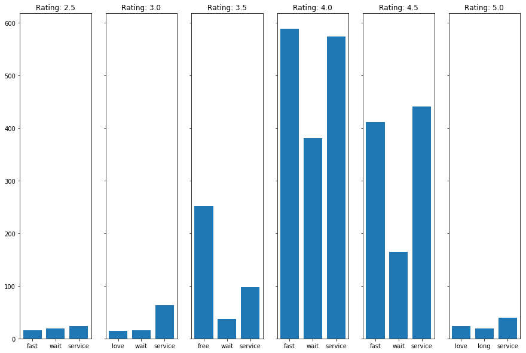

## Modeling and analysis 💻

To analyze the relationship between each of our 15 keywords and the business rating, we ran a multivariate linear regression, with each word as a covariate:

OLS Regression Results

| Dep. Variable: | rating | R-squared: | 0.332 |
| --- | --- | --- | --- |
| Model: | OLS | Adj. R-squared: | 0.212 |
| Method: | Least Squares | F-statistic: | 2.778 |
| Date: | Thu, 08 Mar 2018 | Prob (F-statistic): | 0.00159 |
| Time: | 03:39:41 | Log-Likelihood: | -35.763 |
| No. Observations: | 100 | AIC: | 103.5 |
| Df Residuals: | 84 | BIC: | 145.2 |
| Df Model: | 15 |  |  |
| Covariance Type: | nonrobust |  |  |

|  | coef | std err | t | P>\|t\| | [0.025 | 0.975] |
| --- | --- | --- | --- | --- | --- | --- |
| Intercept | 3.9081 | 0.080 | 48.550 | 0.000 | 3.748 | 4.068 |
| love | 0.0109 | 0.008 | 1.365 | 0.176 | -0.005 | 0.027 |
| friendly | 0.0442 | 0.013 | 3.392 | 0.001 | 0.018 | 0.070 |
| free | -0.0031 | 0.002 | -1.688 | 0.095 | -0.007 | 0.001 |
| fast | 0.0060 | 0.004 | 1.600 | 0.113 | -0.001 | 0.013 |
| happy | 0.0012 | 0.021 | 0.059 | 0.953 | -0.041 | 0.043 |
| wait | -0.0070 | 0.006 | -1.084 | 0.281 | -0.020 | 0.006 |
| closed | -0.0377 | 0.034 | -1.106 | 0.272 | -0.105 | 0.030 |
| busy | -0.0114 | 0.025 | -0.448 | 0.655 | -0.062 | 0.039 |
| long | 0.0114 | 0.016 | 0.733 | 0.465 | -0.020 | 0.042 |
| slow | -0.0318 | 0.033 | -0.959 | 0.340 | -0.098 | 0.034 |
| service | -0.0057 | 0.006 | -0.991 | 0.324 | -0.017 | 0.006 |
| atmosphere | 0.0081 | 0.013 | 0.616 | 0.539 | -0.018 | 0.034 |
| location | -0.0277 | 0.019 | -1.463 | 0.147 | -0.065 | 0.010 |
| wifi | -0.0660 | 0.036 | -1.848 | 0.068 | -0.137 | 0.005 |
| donuts | 0.0615 | 0.060 | 1.029 | 0.307 | -0.057 | 0.180 |

| Omnibus: | 20.448 | Durbin-Watson: | 1.953 |
| --- | --- | --- | --- |
| Prob(Omnibus): | 0.000 | Jarque-Bera (JB): | 36.337 |
| Skew: | -0.835 | Prob(JB): | 1.29e-08 |
| Kurtosis: | 5.435 | Cond. No. | 59.0 |

### Interpreting the results:

- Looking at the **coefficients**, our results indicate both positive and negative relationships between words and the business rating:
  - **Love**, **friendly**, **fast**, **happy**, **long**, **atmosphere**, and **donuts** all have positive coefficients, which indicate that for a +1 increase in frequency of these words mentioned, there is an increase in the business' rating. This is consistent with our categorization of the words, with 4/5 positive words having this positive relationship. We hypothesize that **long** having this positive relationship can be correlated with how popular a business is - more visitors equals longer lines!
  - **Free**, **wait**, **closed**, **busy**, **slow**, **service**, **location**, and **wifi** all had negative coefficients, which indicate that for a +1 increase in frequency of these words mentioned, there is an decrease in the business' rating. This is also consistent with our categorizations - 4/5 negative words had this negative coefficient. We also hypothesized that customers are more likely to complain rather than compliment service and location.
- Looking at our **p-values**, there is actually only **one** word that indicates strong evidence against the null hypothesis (no words have any impact on business rating): **friendly**!
  - The p-value for **friendly** is 0.001, so p < 0.05, and therefore we can reject the null hypothesis.
  - **Friendly** also has one of the highest positive coefficients, 0.0442.
- The **R^2 value** of our model is 0.332. This is justified as tips are not connected to a users' star rating of the business, and an individual word can only represent a subset of the overall sentiment of the tip, as noted in our exploration of tips of different business ratings that included each word.

## Conclusion 💭

Understanding customer feedback is critical to a business' success, and feedback comes in all forms, be it in-person conversations, emails, phone calls, or online. While Yelp reviews are a direct source of user feedback that allows users to rate a business and write in-depth about their experience, **Yelp tips** are the tl;dr, no-nonsense version of reviews that we were interested in exploring further.

We found that Yelp tips were a mix of recommendations for the business, and recommendations for other customers. By analyzing a variety of frequently mentioned words - positive words, negative words, and neutral features - in user-submitted tips, we were able to gain a better understanding of the relationship between these business attributes and user sentiments, and the business' overall rating.